# IDS 435 - Optimization via Gurobi

##### Spring 2022

- Installing Gurobi
- A Procedure to Model an Optimization Problem in Gurobi
- A Toy Example
- Marketing Campaign Optimization
- Linear Regression

### **Installing Gurobi**

We follow the Gurobi installation guidelines on [this page](https://www.gurobi.com/documentation/9.5/quickstart_mac/cs_anaconda_and_grb_conda_.html).

1. Run the following lines in your anaconda terminal to add Gurobi repository and install it:
   - `conda config --add channels https://conda.anaconda.org/gurobi`
   - `conda install gurobi`
2. Set up academic license:
   - Sign up at the [Gurobi website](https://www.gurobi.com/login/) using your UIC email.
   - Log into your account.
   - Visit [Academic License Registration page](https://www.gurobi.com/downloads/end-user-license-agreement-academic/).
   - Accept terms and conditions.
   - Copy and paste the code generated by Gurobi (i.e., `grbgetkey 11111111-1111-1111-111-1111111111`) into your operating system's terminal and run it.
   - Your academic license should be set up!
3. Create a Jupyter notebook and test if you can run the code below in your notebook or not. If Gurobi is installed properly, then following code must run without any error.

```python
""" Testing Gurobi Installation"""

import gurobipy as gb
model = gb.Model('Test')
```

```
Set parameter Username
Academic license - for non-commercial use only - expires 2022-05-07
```

### **A Procedure to Model an Optimization Problem in Gurobi**

The main task to use Gurobi in practice is to convert the mathematical formulation of an optimization problem into a Gurobi model that can be solved efficiently.

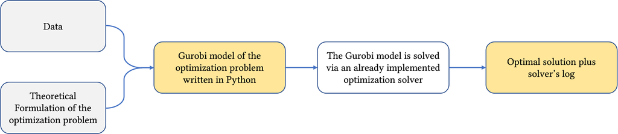

##### **The Procedure**

1. Sets and indices

   Use python `list`, `range`, `arrange`, etc to define index sets to count over decision variables and constraints.
1. Parameters (i.e., data)

   Data should be formatted in a way that is easy to define decision variables, objective function, and constraints in Gurobi. Data can be represented in different formats such as
   - Python lists
   - Python dictionaries
   - Numpy array
   - Pandas `dataframe`
   - Gurobi multidict Since Numpy arrays are widely-used data structures in python, we employ them to represent data that later on used in a Gurobi model
2. Decision variables
   - Specify type of the variable (real-valued, binary, integer, etc)
   - Specify if the variable is signed or not (positive or negative)
   - Try to define put related decision variables of the model in an array of variables instead of defining them individually

     ```
     # For loop
       for i in range (N):
               model.addVar( ... )

       # One line definition
       model.addMvar( shape=N)
     ```

3. Constraints
   - Specify type of a constraint (linear, quadratic, etc)
   - Find an appropriate Gurobi function to model the constraint (oftentimes you can use `addConstrs`)
   - Try to define multiple constraints in a single line of code via python inline for loop

     ```
     # For loop
       for i in range (N):
               model.addConstr( ... )

        # Inline for loop (preferred)
       model.addConstrs( ... for i in range (N))
     ```

4. Objective function
   - Define the objective function using data and decision variables
   - Specify if the problem is maximization or minimization
5. Optimize
   - Choose a solver
   - Specify parameters of the solver (i.e., stopping criteria, feasibility tolerance, etc)
   - Solve the Gurobi model
6. Analyze results (*Gurobi solved the model*)
   - Is model well-conditioned (i.e., no numerical issues encountered while optimization)?
   - Is the model "normalized"?
   - What is an optimal solution?
   - What is the optimal value?
   - How long did it take to solve the model?
7. Troubleshooting (*Gurobi could not solved the model*)
   - Is the issue with the numerical errors?
   - Is the issue with solver? Try a different optimization solver. Try to change the parameters of the solver (i.e., feasibility tolerance)?
   - Double-check the type of variables and their signs as well as the definition of constraints Gurobi model?

### **A Toy Example**

We use the following optimization problem to illustrate using Gurobi and aforementioned procedure for using Gurobi: $$ \begin{aligned} \min_{x_1,x_2} & \quad -x_1 - x_2\\ & \quad x_1 + 2x_2 \le 1\\ & \quad 2x_1 + x_2 \le 1\\ & \quad x_1,x_2\ge 0 \end{aligned} $$

```python
import gurobipy as gb
import numpy as np

if __name__ == "__main__":

    """         Step 1. Sets and indices            """

    """         Step 2. Parameters                  """

    """         Step 3. Decision variables          """

    model   = gb.Model('Toy Example')
    x_1     = model.addVar(name     = 'x_1',
                        vtype    = gb.GRB.CONTINUOUS,
                        lb       = 0,
                        ub       =  gb.GRB.INFINITY )

    x_2     = model.addVar(name     = 'x_2',
                        vtype    = gb.GRB.CONTINUOUS,
                        lb       = 0,
                        ub       =  gb.GRB.INFINITY )

    """         Step 4. Constraints                 """
    model.addConstr(x_1 + 2*x_2  <= 1)
    model.addConstr(2*x_1 + x_2  <= 1)

    """         Step 5. Objective function          """
    model.setObjective(-x_1 - x_2)

    """         Step 6. Optimize                    """
    print('='*100)
    model.setParam('Method',2)
    model.setParam('Crossover',0)
    model.update()
    model.optimize()
    print('='*100)

    """         Step 7. Analyze results         """
    print('The optimal x_1:         \t',        x_1.X)
    print('The optimal x_2:         \t',        x_2.X)
    print('The optimal value is:    \t',        model.ObjVal)
    print('='*100)
```

```
====================================================================================================
Set parameter Method to value 2
Set parameter Crossover to value 0
Gurobi Optimizer version 9.5.1 build v9.5.1rc2 (mac64[rosetta2])
Thread count: 10 physical cores, 10 logical processors, using up to 10 threads
Optimize a model with 2 rows, 2 columns and 4 nonzeros
Model fingerprint: 0xed33d8fe
Coefficient statistics:
  Matrix range     [1e+00, 2e+00]
  Objective range  [1e+00, 1e+00]
  Bounds range     [0e+00, 0e+00]
  RHS range        [1e+00, 1e+00]
Presolve time: 0.00s
Presolved: 2 rows, 2 columns, 4 nonzeros
Ordering time: 0.00s

Barrier statistics:
 AA' NZ     : 1.000e+00
 Factor NZ  : 3.000e+00
 Factor Ops : 5.000e+00 (less than 1 second per iteration)
 Threads    : 1

                  Objective                Residual
Iter       Primal          Dual         Primal    Dual     Compl     Time
   0  -8.67927042e-01 -4.61538462e-01  1.51e-01 3.08e-01  2.86e-01     0s
   1  -6.05231787e-01 -6.96010401e-01  0.00e+00 0.00e+00  2.27e-02     0s
   2  -6.66536989e-01 -6.66799107e-01  0.00e+00 0.00e+00  6.55e-05     0s
   3  -6.66666537e-01 -6.66666799e-01  0.00e+00 0.00e+00  6.55e-08     0s
   4  -6.66666667e-01 -6.66666667e-01  0.00e+00 2.22e-16  6.55e-11     0s

Barrier solved model in 4 iterations and 0.01 seconds (0.00 work units)
Optimal objective -6.66666667e-01

====================================================================================================
The optimal x_1:         	 0.3333333332685205
The optimal x_2:         	 0.3333333332685205
The optimal value is:    	 -0.666666666537041
====================================================================================================
```

##### What is happening?

[figure not shown]

##### **A Finer Implementation**

```python
import gurobipy as gb
import numpy as np

if __name__ == "__main__":

    """         Step 1. Sets and indices            """
    num_var          = 2
    num_constr       = 2
    var_index        = range(num_var)
    constr_index     = range(num_constr)

    """         Step 2. Parameters                  """
    constr_matrix    = np.array([[1.,2.],[2.,1.]])
    rhs              = np.array([1.,1.])


    """         Step 3. Decision variables          """

    model           = gb.Model('Toy Example')
    x               = model.addMVar(
                                    shape    = num_var,
                                    name     = 'x',
                                    vtype    = gb.GRB.CONTINUOUS,
                                    lb       = 0.,
                                    ub       = gb.GRB.INFINITY )

    """         Step 4. Constraints                 """
    model.addConstrs(gb.quicksum(constr_matrix[i][j]*x[j]  for j in var_index) <= rhs[i]    for i in constr_index)

    """         Step 5. Objective function          """
    model.setObjective(-gb.quicksum(x))

    """         Step 6. Optimize                    """
    print('='*100)
    model.setParam('Method',2)
    model.setParam('Crossover',0)
    model.update()
    model.optimize()
    print('='*100)

    """         Step 7. Analyze results             """
    print('The optimal x_1:         \t',        x[0].X)
    print('The optimal x_2:         \t',        x[1].X)
    print('The optimal value is:    \t',        model.ObjVal)
    print('='*100)
```

```
Set parameter Username
Academic license - for non-commercial use only - expires 2022-05-07
====================================================================================================
Set parameter Method to value 2
Set parameter Crossover to value 0
Gurobi Optimizer version 9.5.1 build v9.5.1rc2 (mac64[rosetta2])
Thread count: 10 physical cores, 10 logical processors, using up to 10 threads
Optimize a model with 2 rows, 2 columns and 4 nonzeros
Model fingerprint: 0xed33d8fe
Coefficient statistics:
  Matrix range     [1e+00, 2e+00]
  Objective range  [1e+00, 1e+00]
  Bounds range     [0e+00, 0e+00]
  RHS range        [1e+00, 1e+00]
Presolve time: 0.00s
Presolved: 2 rows, 2 columns, 4 nonzeros
Ordering time: 0.00s

Barrier statistics:
 AA' NZ     : 1.000e+00
 Factor NZ  : 3.000e+00
 Factor Ops : 5.000e+00 (less than 1 second per iteration)
 Threads    : 1

                  Objective                Residual
Iter       Primal          Dual         Primal    Dual     Compl     Time
   0  -8.67927042e-01 -4.61538462e-01  1.51e-01 3.08e-01  2.86e-01     0s
   1  -6.05231787e-01 -6.96010401e-01  0.00e+00 0.00e+00  2.27e-02     0s
   2  -6.66536989e-01 -6.66799107e-01  0.00e+00 0.00e+00  6.55e-05     0s
   3  -6.66666537e-01 -6.66666799e-01  0.00e+00 0.00e+00  6.55e-08     0s
   4  -6.66666667e-01 -6.66666667e-01  0.00e+00 2.22e-16  6.55e-11     0s

Barrier solved model in 4 iterations and 0.01 seconds (0.00 work units)
Optimal objective -6.66666667e-01

====================================================================================================
The optimal x_1:         	 0.3333333332685205
The optimal x_2:         	 0.3333333332685205
The optimal value is:    	 -0.666666666537041
====================================================================================================
```

##### What is happening?

[figure not shown]